# Prosper Loan Data

Kelly Downes

October 23, 2017

========================================================

# Introduction

This report explores a dataset of 113,937 loans with 81 variables for each loan. These variables include information about the loan such as the amount, rate, length, and status, as well as information on the borrower, such as credit grade, income range, and employment status.

Let’s look at the structure of this dataset:

```
## 'data.frame':    113937 obs. of  81 variables:
##  $ ListingKey                         : Factor w/ 113066 levels "00003546482094282EF90E5",..: 7180 7193 6647 6669 6686 6689 6699 6706 6687 6687 ...
##  $ ListingNumber                      : int  193129 1209647 81716 658116 909464 1074836 750899 768193 1023355 1023355 ...
##  $ ListingCreationDate                : Factor w/ 113064 levels "2005-11-09 20:44:28.847000000",..: 14184 111894 6429 64760 85967 100310 72556 74019 97834 97834 ...
##  $ CreditGrade                        : Factor w/ 9 levels "","A","AA","B",..: 5 1 8 1 1 1 1 1 1 1 ...
##  $ Term                               : int  36 36 36 36 36 60 36 36 36 36 ...
##  $ LoanStatus                         : Factor w/ 12 levels "Cancelled","Chargedoff",..: 3 4 3 4 4 4 4 4 4 4 ...
##  $ ClosedDate                         : Factor w/ 2803 levels "","2005-11-25 00:00:00",..: 1138 1 1263 1 1 1 1 1 1 1 ...
##  $ BorrowerAPR                        : num  0.165 0.12 0.283 0.125 0.246 ...
##  $ BorrowerRate                       : num  0.158 0.092 0.275 0.0974 0.2085 ...
##  $ LenderYield                        : num  0.138 0.082 0.24 0.0874 0.1985 ...
##  $ EstimatedEffectiveYield            : num  NA 0.0796 NA 0.0849 0.1832 ...
##  $ EstimatedLoss                      : num  NA 0.0249 NA 0.0249 0.0925 ...
##  $ EstimatedReturn                    : num  NA 0.0547 NA 0.06 0.0907 ...
##  $ ProsperRating..numeric.            : int  NA 6 NA 6 3 5 2 4 7 7 ...
```

[output cut: 67 more lines]

Here is a summary of this dataset:

```
##                    ListingKey     ListingNumber
##  17A93590655669644DB4C06:     6   Min.   :      4
##  349D3587495831350F0F648:     4   1st Qu.: 400919
##  47C1359638497431975670B:     4   Median : 600554
##  8474358854651984137201C:     4   Mean   : 627886
##  DE8535960513435199406CE:     4   3rd Qu.: 892634
##  04C13599434217079754AEE:     3   Max.   :1255725
##  (Other)                :113912
##                     ListingCreationDate  CreditGrade         Term
##  2013-10-02 17:20:16.550000000:     6          :84984   Min.   :12.00
##  2013-08-28 20:31:41.107000000:     4   C      : 5649   1st Qu.:36.00
##  2013-09-08 09:27:44.853000000:     4   D      : 5153   Median :36.00
##  2013-12-06 05:43:13.830000000:     4   B      : 4389   Mean   :40.83
##  2013-12-06 11:44:58.283000000:     4   AA     : 3509   3rd Qu.:36.00
##  2013-08-21 07:25:22.360000000:     3   HR     : 3508   Max.   :60.00
##  (Other)                      :113912   (Other): 6745
##                  LoanStatus                  ClosedDate
##  Current              :56576                      :58848
##  Completed            :38074   2014-03-04 00:00:00:  105
##  Chargedoff           :11992   2014-02-19 00:00:00:  100
##  Defaulted            : 5018   2014-02-11 00:00:00:   92
##  Past Due (1-15 days) :  806   2012-10-30 00:00:00:   81
##  Past Due (31-60 days):  363   2013-02-26 00:00:00:   78
##  (Other)              : 1108   (Other)            :54633
##   BorrowerAPR       BorrowerRate     LenderYield
##  Min.   :0.00653   Min.   :0.0000   Min.   :-0.0100
##  1st Qu.:0.15629   1st Qu.:0.1340   1st Qu.: 0.1242
##  Median :0.20976   Median :0.1840   Median : 0.1730
##  Mean   :0.21883   Mean   :0.1928   Mean   : 0.1827
##  3rd Qu.:0.28381   3rd Qu.:0.2500   3rd Qu.: 0.2400
##  Max.   :0.51229   Max.   :0.4975   Max.   : 0.4925
##  NA's   :25
##  EstimatedEffectiveYield EstimatedLoss   EstimatedReturn
##  Min.   :-0.183          Min.   :0.005   Min.   :-0.183
##  1st Qu.: 0.116          1st Qu.:0.042   1st Qu.: 0.074
##  Median : 0.162          Median :0.072   Median : 0.092
##  Mean   : 0.169          Mean   :0.080   Mean   : 0.096
##  3rd Qu.: 0.224          3rd Qu.:0.112   3rd Qu.: 0.117
##  Max.   : 0.320          Max.   :0.366   Max.   : 0.284
##  NA's   :29084           NA's   :29084   NA's   :29084
```

[output cut: 193 more lines]

```
##  Min.   :    0.00                Min.   :0.7000   Min.   : 0.00000
##  1st Qu.:    0.00                1st Qu.:1.0000   1st Qu.: 0.00000
##  Median :    0.00                Median :1.0000   Median : 0.00000
##  Mean   :   25.14                Mean   :0.9986   Mean   : 0.04803
##  3rd Qu.:    0.00                3rd Qu.:1.0000   3rd Qu.: 0.00000
##  Max.   :21117.90                Max.   :1.0125   Max.   :39.00000
##
##  InvestmentFromFriendsCount InvestmentFromFriendsAmount   Investors
##  Min.   : 0.00000           Min.   :    0.00            Min.   :   1.00
##  1st Qu.: 0.00000           1st Qu.:    0.00            1st Qu.:   2.00
##  Median : 0.00000           Median :    0.00            Median :  44.00
##  Mean   : 0.02346           Mean   :   16.55            Mean   :  80.48
##  3rd Qu.: 0.00000           3rd Qu.:    0.00            3rd Qu.: 115.00
##  Max.   :33.00000           Max.   :25000.00            Max.   :1189.00
##
```

# Univariate Plots

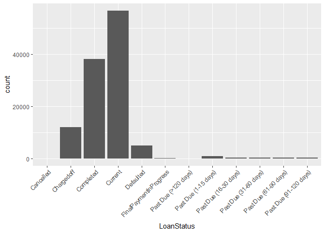

In this plot we can see that the majority of loans are current or completed. However, it may be useful to view the categories in a different order. I’ll rearrange this variable here:

```r
#rearrange loan status

loans$LoanStatus <- factor(loans$LoanStatus,
                           levels = c("Completed", "FinalPaymentInProgress",
                                      "Current", "Past Due (1-15 days)",
                                      "Past Due (16-30 days)",
                                      "Past Due (31-60 days)",
                                      "Past Due (61-90 days)",
                                      "Past Due (91-120 days)",
                                      "Past Due (>120 days)",
                                      "Chargedoff", "Defaulted", "Cancelled"))
```

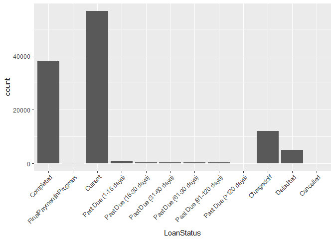

Now this category is arranged from completed to cancelled loans.

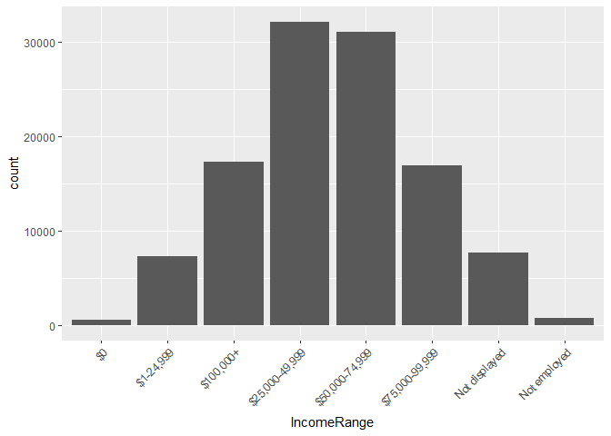

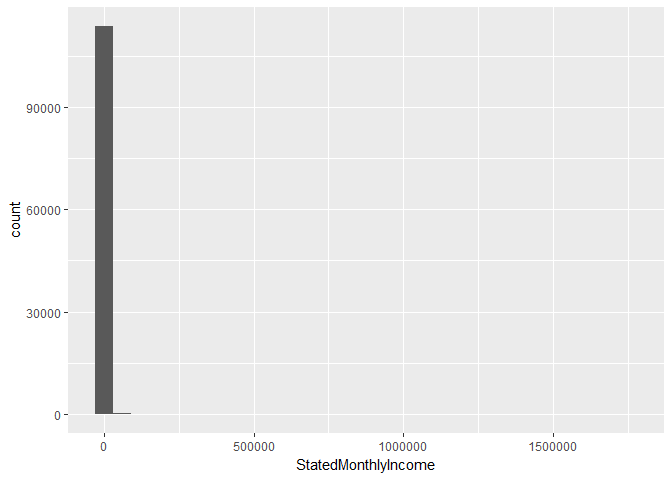

These two plots show income range and stated monthly income. There are a few issues with these plots. The income range variable is out of order and the monthly income is being skewed by some high earners. I can adjust the graph to leave out the top high earners, but I would also like to see this variable converted to an annual income. I will convert this variable and rearrange the income range variable:

```r
#rearrange income range

loans$IncomeRange <- factor(loans$IncomeRange,
                            levels = c("Not displayed","Not employed", "$0",
                                       "$1-24,999", "$25,000-49,999",
                                       "$50,000-74,999", "$75,000-99,999",
                                       "$100,000+"))
```

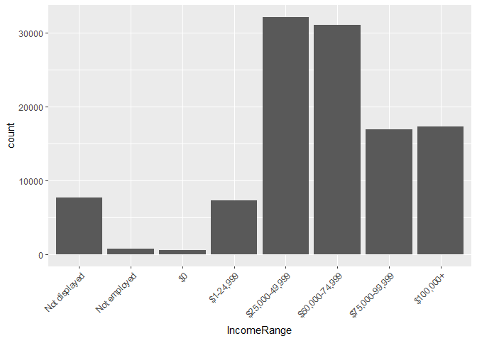

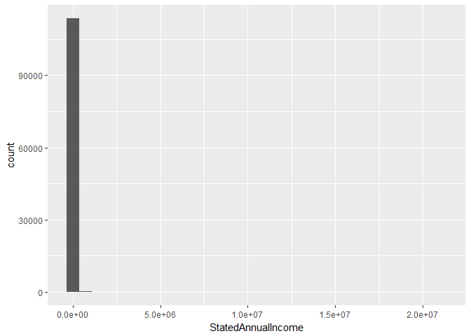

```r
#create annual income variable from stated monhly income

loans$StatedAnnualIncome <- loans$StatedMonthlyIncome * 12

qplot(data = loans, x = StatedAnnualIncome)
```

```r
summary(loans$StatedAnnualIncome)
```

```
##     Min.  1st Qu.   Median     Mean  3rd Qu.     Max.
##        0    38400    56000    67300    81900 21000000
```

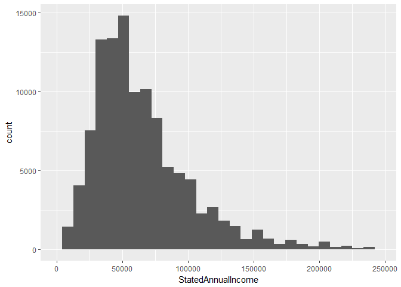

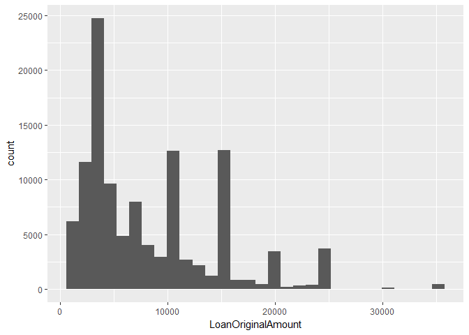

[output not shown]

```r
#adjust plot so we can see annual income without top 1% of earner

qplot(data = loans, x = StatedAnnualIncome) +
  scale_x_continuous(lim = c(0, quantile(loans$StatedAnnualIncome, 0.99)))
```

Here we can see that the shape of orignal loan amount is right skewed, with many peaks around roughly $5k intervals.

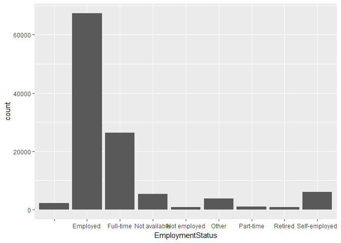

```r
#adjust employment status variable

loans$EmploymentAdjusted<- factor(loans$EmploymentStatus,
                                  levels = c("Employed", "Full-time",
                                             "Part-time", "Self-employed",
                                             "Not employed", "Retired"))
```

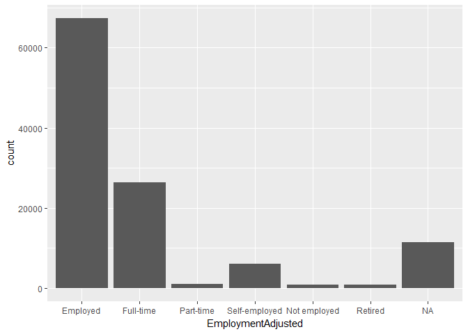

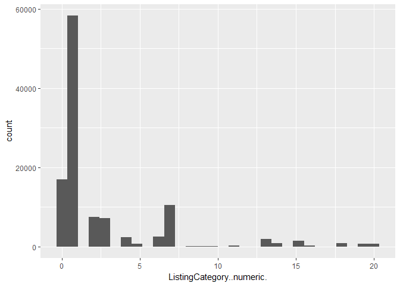

This plot of listing category shows that some categories are much more popular than others. However, we would need to reference the variable dictionary to see what these are. I will create a new variable which stores the category names as factors.

```r
#convert numeric categories
loans$ListingCategory <- cut(loans$ListingCategory..numeric.,
                             breaks = c(0,1,2,3,4,5,6,7,8,9,10,11,12,13,14,15,
                                        16,17,18,19,20,21),
                             labels = c("Not Available", "Debt Consolidation",
                                        "Home Improvement", "Business",
                                        "Personal Loan", "Student Use", "Auto",
                                        "Other", "Baby&Adoption", "Boat",
                                        "Cosmetic Procedure", "Engagement Ring",
                                        "Green Loans", "Household Expenses",
                                        "Large Purchases", "Medical/Dental",
                                        "Motorcycle", "RV", "Taxes", "Vacation",
                                        "Wedding Loans"), right = FALSE)
```

```
##  [1] "Not Available"      "Debt Consolidation" "Home Improvement"
##  [4] "Business"           "Personal Loan"      "Student Use"
##  [7] "Auto"               "Other"              "Baby&Adoption"
## [10] "Boat"               "Cosmetic Procedure" "Engagement Ring"
## [13] "Green Loans"        "Household Expenses" "Large Purchases"
## [16] "Medical/Dental"     "Motorcycle"         "RV"
## [19] "Taxes"              "Vacation"           "Wedding Loans"
```

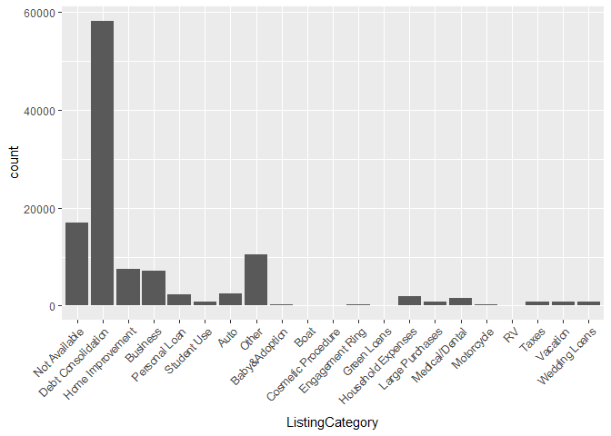

This plot shows that debt consolidation is by far the largest category. The next two categories are not available, and other. Of the other names categories, the next largest are home improvement and business.

```r
#create loan origination year and month variables from loan origination date

loans$LoanOriginationYear <- as.factor(year(loans$LoanOriginationDate))
loans$LoanOriginationMonth <- as.factor(month(loans$LoanOriginationDate))


#remove year from loan origination quarter variable
loans$LoanQuarter <- substr(loans$LoanOriginationQuarter,1-2,2)
```

I created a few more variables. We have a loan origination date variable which has the day, month, and year for each loan. I’ve created a variable that has just the year, and one that has just the month. I’ve also created a variable that will have just the quarter of the loan, without the year.

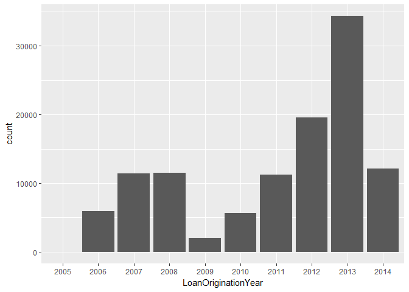

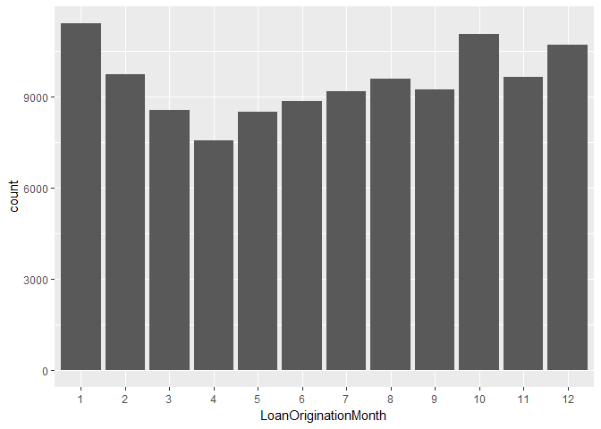

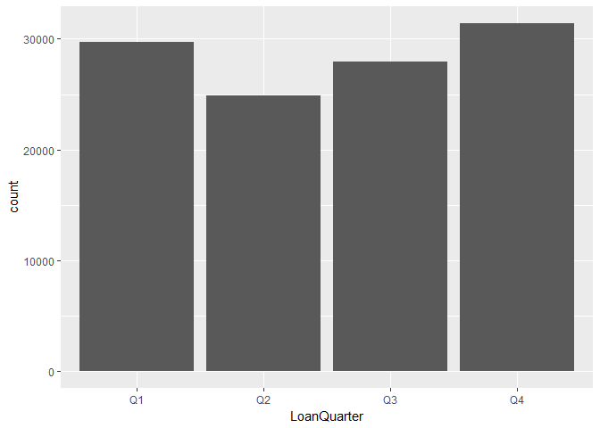

These three plots show when each loan started, broken down by each year, month, and quarter. There are very few loans started in 2005, so it is likely that Prosper either started with a small number of loans at the end of 2005, or that the data collection for this dataset started at the end of 2005. We can see a dropoff in loans in 2009 (which could be correlated with the recession), then the number of loans builds up each year to a high in 2013. This year has way more loans than any other year; it may be interesting to look at this year more in depth as it has the most data.

On average, April has the lowest number of loans started, and January the highest. The second quarter has the least amount of loans, and the fourth quarter the highest.

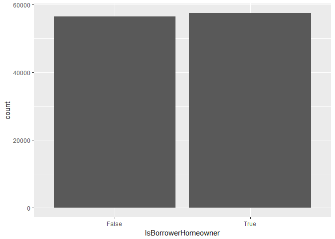

In this plot we can see that the number of homeowners is only slighly higher than non homeowners.

```r
#create credit score mean variable
loans$CreditScoreMean <- (loans$CreditScoreRangeLower +
                            loans$CreditScoreRangeUpper)/2

#create credit score category variable
loans$CreditScoreCategory <- cut(loans$CreditScoreMean,
                                 breaks = c(0, 550, 650, 700, 750, 900),
                                 labels = c("Bad", "Poor", "Fair", "Good",
                                            "Excellent"),
                                 include.lowest = TRUE,
                                 right = FALSE)
```

There is a credit score range lower variable, and a credit score range upper variable. I’ve created a new variable which takes the mean of these two numbers, so we can use this one variable in our analysis. I’ve then created another variable which breaks up the mean credit scores into categories: Bad - Under 550, Poor - 550-650, Fair - 650-700, Good - 700-750, and Excellent - 750 and higher.

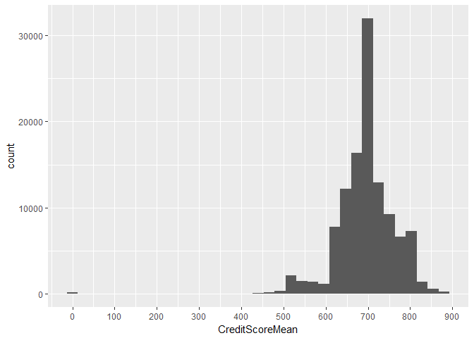

```
##    Min. 1st Qu.  Median    Mean 3rd Qu.    Max.    NA's
##     9.5   669.5   689.5   695.1   729.5   889.5     591
```

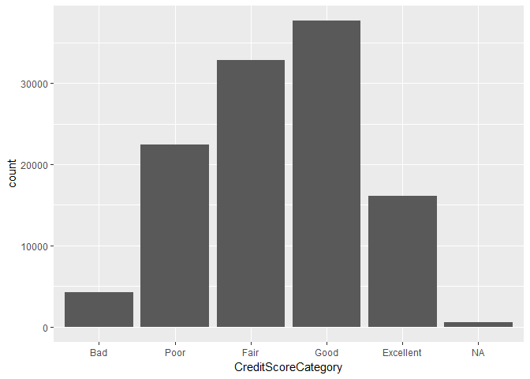

In the first plot we can see that the mean credit score for a small amount of borrowers is 0. The rest of the borrowers scores start at 450, with most borrowers having mean credit scores ranging between 625 and 725. The largest group by far appears to be about 680 - 710.

When we look at the credit score category graph, we can see the largest groups are Fair and Good.

# Univariate Analysis

For this report, the main features of interest in this dataset will be loan status, income, and credit score. Other features of interest are loan origination year, whether or not the borrower is a homeowner, and listing category.

To aid my analysis, I have created a few new variables from the existing variables in this dataset. I made ListingCategory..numeric. into a categorical variable with the categories listed as factors. I made loan origination month and year variables from loan origination date. I made a variable for loan quarter which just has the quarter without the year. I made a credit score mean variable from the credit score upper range and lower range variables. From this credit score mean, I made a credit score category. I made a stated annual income variable from the stated monthly income variable. I made an adjusted employment variable which combines the “”, “Not available”, and “Other” levels of employment status into one NA level.

I rearranged the order of loan status and income range so that they will appear in a logical fashion when graphed.

# Bivariate Plots

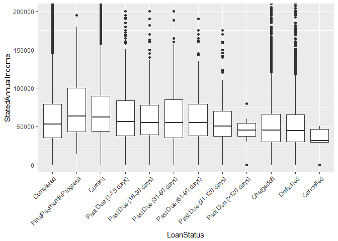

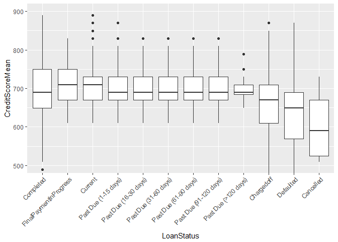

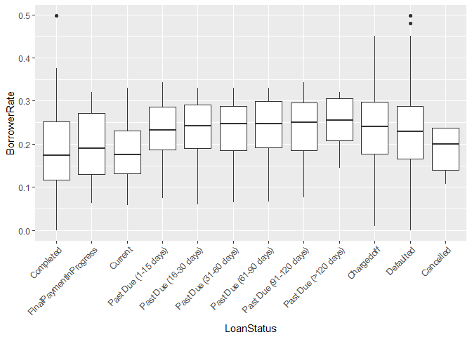

In the first plot we can see that the final payment in progress group has a slightly higher median stated annual income than the other groups, while the cancelled group has the lowest. The IQR for the loans that are past due over 120 days is smaller.

In the third plot, there is a slight upward trend for the past due groups, where the borrower rate increases. The current and completed groups have similar borrower rates.

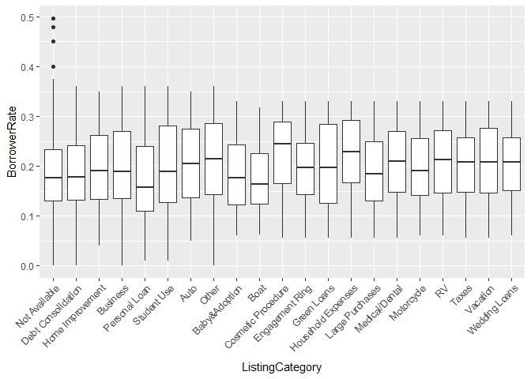

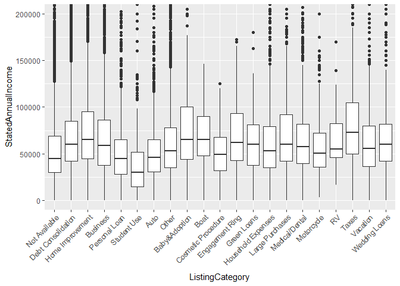

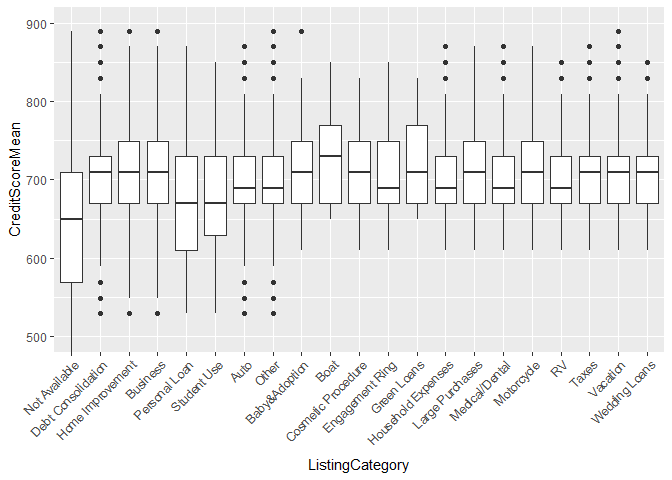

In these plots we can see that the median borrower rate is highest for cosmetic procedures and lowest for personal loans, however the stated annual income median and IQR is similar for these two groups. Student use has the lowest stated annual income, whereas taxes have the highest. The personal loan and student use groups have the largest IQR and lowest medians, after the not available group.

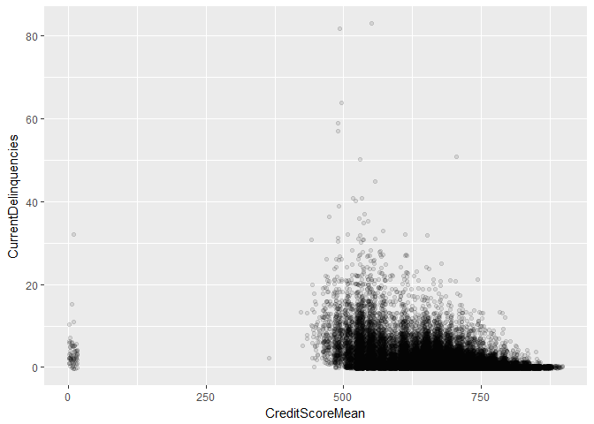

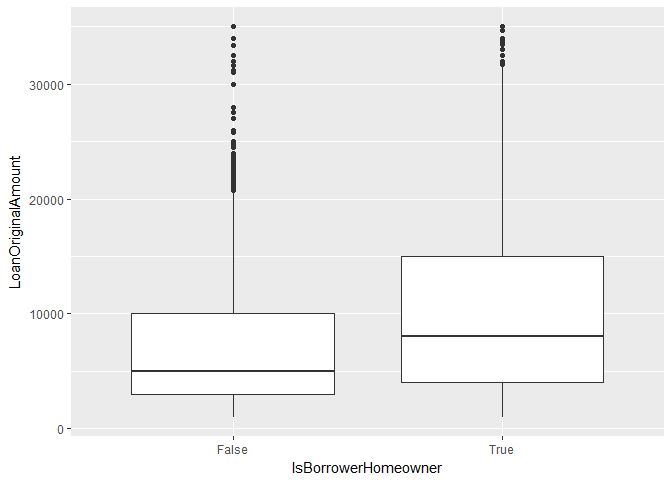

The median original loan amount for homeowners is higher, along with the IQR.

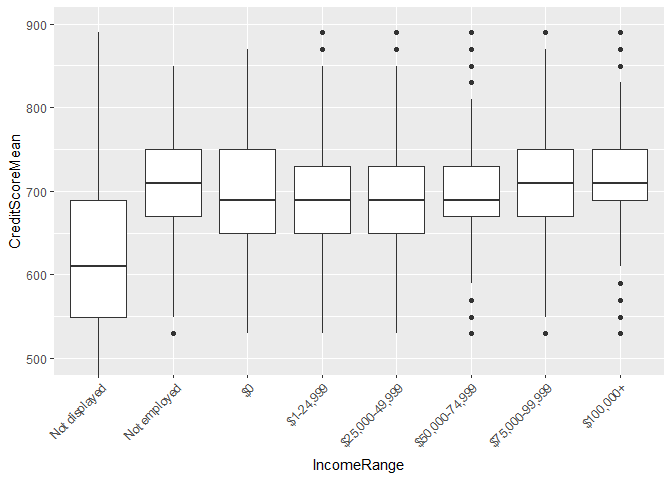

In this plot, we can see that the not employed group has a higher credit score mean than the groups who earn less than $75k.

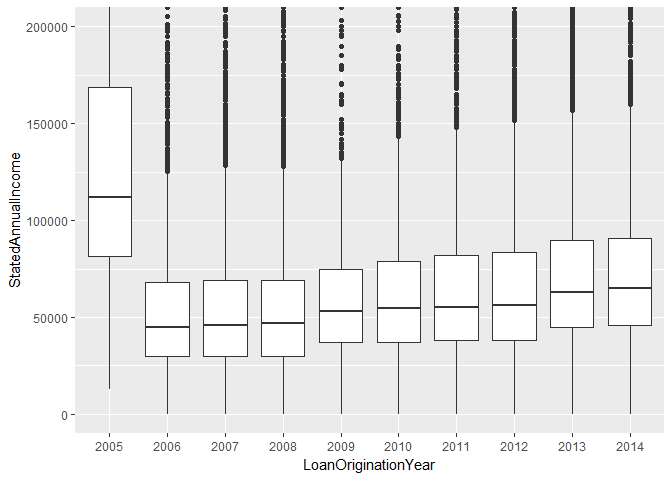

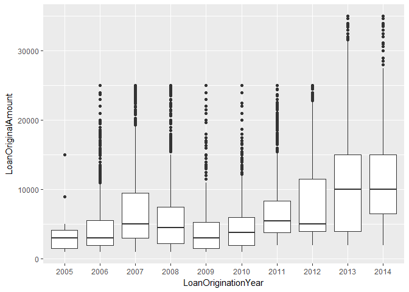

In the first plot, we can see that the stated annual income rises slightly each year from 2006-2014. The income for 2005 is noticeably higher than the other groups. We saw earlier that there are very few loans from 2005 in this dataset. Due to this small sample size, it isn’t as representative of the data as a whole compared to the other groups which contain many more loans.